# Batting

Jim Albert

2022-10-30

### Illustration of some tidyverse work to explore the Batting table in the Lahman database

I load in three packages:

- the Lahman package contains the baseball data
- the dplyr package is part of the tidyverse suite of packages useful for manipulation of data frames
- the ggplot2 package allows us to create graphs

```r
library(Lahman)
library(dplyr)
library(ggplot2)
```

The Lahman database contains season-to-season data for MLB seasons from the beginning to the 2021 season.

The Batting table is a data frame with 110,495 observations with 22 variables.

**Question: Which player had the highest career batting average between 1990 and 2020?**

Here I start with the Batting data frame:

– filter the data to get only the stats for the seasons between 1990 and 2020 – for each player, find the cumulative H and AB (do this by the group_by and summarize functions)

```r
Batting %>%
  filter(yearID >= 1990,
         yearID <= 2020) %>%
  group_by(playerID) %>%
  summarize(H = sum(H),
            AB = sum(AB)) -> S
```

Here is what this new data frame S looks like:

```r
head(S)
```

```
## # A tibble: 6 × 3
##   playerID      H    AB
##   <chr>     <int> <int>
## 1 aardsda01     0     4
## 2 aasedo01      0     0
## 3 abadan01      2    21
## 4 abadfe01      1     9
## 5 abbotje01   157   596
## 6 abbotji01     2    21
```

I only want to consider players who have had at least 1000 AB during this period. I will call the new data frame S1000.

```r
S %>%
  filter(AB >= 1000) -> S1000
```

Next, I compute the batting average for each player – round to three decimal places.

```r
S1000 %>%
  mutate(AVG = round(H / AB, 3)) -> S1000
```

Last, I sort this data frame by AVG from highest to lowest:

```r
S1000 %>%
  arrange(desc(AVG)) -> S1000
```

Use the head function to show the top 10:

```r
head(S1000, 10) -> Top_AVG
Top_AVG
```

```
## # A tibble: 10 × 4
##    playerID      H    AB   AVG
##    <chr>     <int> <int> <dbl>
##  1 gwynnto01  1787  5210 0.343
##  2 guerrvl01  2590  8155 0.318
##  3 heltoto01  2519  7962 0.316
##  4 walkela01  2152  6860 0.314
##  5 cabremi01  2866  9153 0.313
##  6 garcino01  1747  5586 0.313
##  7 martied01  2181  6967 0.313
##  8 molitpa01  1568  5007 0.313
##  9 puckeki01  1061  3400 0.312
## 10 ramirma02  2574  8244 0.312
```

It would be helpful to add the names of these players. The People data frame contains info about each player including their player code, first and last names. I will select specific variables from the People data frame and merge this information with my batting tab.e

```r
inner_join(Top_AVG,
           select(People, playerID,
                  nameFirst, nameLast),
           by = "playerID") -> Top_AVG
```

Now I display the names and top averages:

```r
Top_AVG %>%
  select(nameFirst, nameLast, AVG)
```

```
## # A tibble: 10 × 3
##    nameFirst nameLast      AVG
##    <chr>     <chr>       <dbl>
##  1 Tony      Gwynn       0.343
##  2 Vladimir  Guerrero    0.318
##  3 Todd      Helton      0.316
##  4 Larry     Walker      0.314
##  5 Miguel    Cabrera     0.313
##  6 Nomar     Garciaparra 0.313
##  7 Edgar     Martinez    0.313
##  8 Paul      Molitor     0.313
##  9 Kirby     Puckett     0.312
## 10 Manny     Ramirez     0.312
```

I create a new variable Name that pastes the first and last names.

```r
Top_AVG %>%
  mutate(Name = paste(nameFirst, nameLast)) ->
  Top_AVG
```

Then I use a dotplot to display these top averages.

The ggplot() function has these inputs:

- first I indicate the data frame to be used
- the aes() function indicates roles – here I want the x variable to be AVG and the y variable to be Name
- the geom_point() is a geometric object to display - here this is a point.
- I add a title to indicate what I am graphing

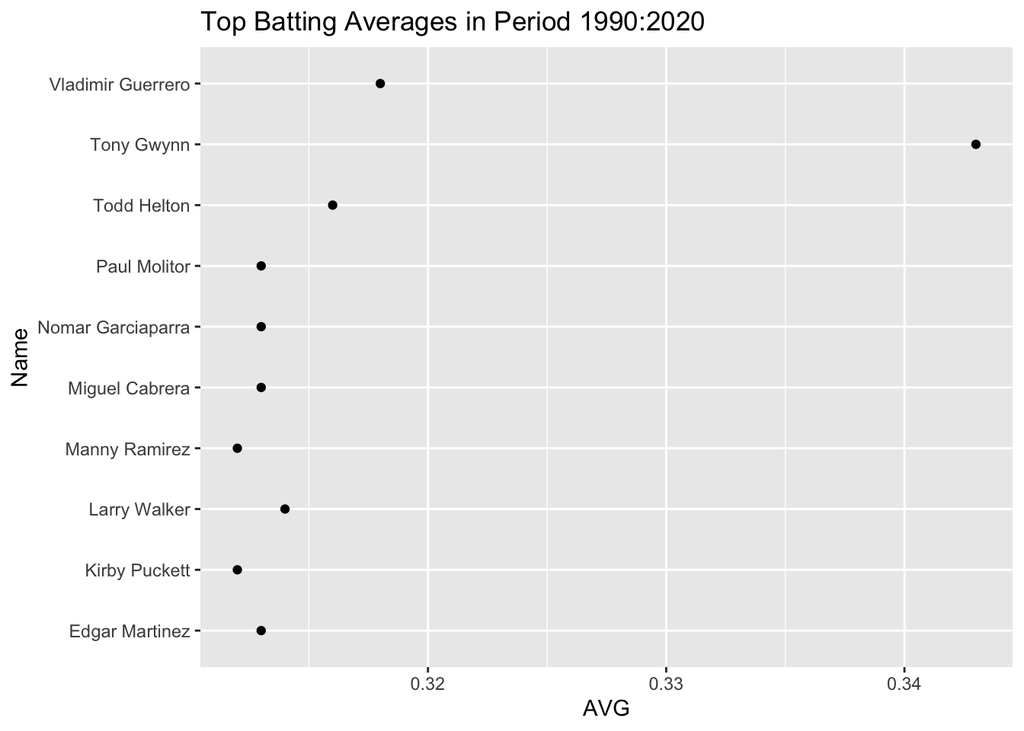

```r
ggplot(Top_AVG,
       aes(AVG, Name)) +
  geom_point() +
  labs(title = "Top Batting Averages in Period 1990:2020")
```

Clearly, Tony Gwynn was the best hitter for average during this period.